# Final Project 2026 — Yacht Hydrodynamic Resistance

## 4. Posterior predictive curves

The last comparison should be made on the original resistance scale, because this is where the data are observed and where the two error assumptions imply visibly different uncertainty bands. For a fair comparison, both bands below are **posterior predictive** bands: each draw includes uncertainty in the mean curve and one new observation-level error term.

For the log-log model, the posterior predictive distribution is lognormal on the original scale: after drawing $(\beta,\sigma^2)$ from the reference-prior posterior, we simulate
$$\log y_i^{\mathrm{rep}} \sim \mathcal N(x_i^\top\beta,\sigma^2),
\qquad y_i^{\mathrm{rep}} = \exp(\log y_i^{\mathrm{rep}}).$$
For the heteroscedasticity-treated nonlinear model M1, the predictive distribution is Gamma on the original scale with mean $\mu_i$ and mean-dependent standard deviation $\sigma_i$:
$$y_i^{\mathrm{rep}} \sim \mathrm{Gamma}\left(\alpha_i,\ r_i\right),\qquad
\mu_i=\exp\{b_0 + \gamma_F\widetilde{\log Fn}_i +
\beta_B\widetilde{bd}_i\},\qquad
\sigma_i=\sigma_0\,\mu_i^{\delta},$$
with $\alpha_i=(\mu_i/\sigma_i)^2$ and $r_i=\mu_i/\sigma_i^2$. This keeps replicated resistances positive by construction while still letting the predictive band widen where the resistance, and hence the scatter, is larger. The curves hold hull form fixed at a representative value: `beam_draught` is set to its sample median, while the other log-log hull covariates are set to their sample means. This isolates the Froude-resistance curve rather than mixing different hull geometries.

```r
set.seed(42)

## Froude grid and representative hull values
fr_grid <- seq(min(yh$Froude), max(yh$Froude), length.out = 160)
bd_ref <- median(yh$beam_draught)
hull_ref <- as.list(colMeans(yh[, c("LCB", "prismatic", "L_disp", "beam_draught", "L_beam")]))
hull_ref$beam_draught <- bd_ref

new_loglog <- data.frame(log_Fr = log(fr_grid), hull_ref)
new_M1 <- cbind(intercept = 1,
                log_Fr = log(fr_grid) - mF,
                beam_draught = bd_ref - mB)

## Draw posterior predictive samples for the reference-prior log-log model.
## beta | sigma2, y is normal; sigma2 | y is inverse-gamma.
draw_loglog_pred <- function(fit, newdata, n_draws = 5000) {
  X <- model.matrix(fit)
  y <- model.response(model.frame(fit))
  p <- ncol(X)
  df_res <- fit$df.residual
  beta_hat <- coef(fit)
  s2 <- sum(resid(fit)^2) / df_res
  XtX_inv <- chol2inv(chol(crossprod(X)))
  X_new <- model.matrix(delete.response(terms(fit)), newdata)

  sigma2 <- df_res * s2 / rchisq(n_draws, df = df_res)
  z <- matrix(rnorm(n_draws * p), nrow = n_draws)
  beta <- sweep(z %*% chol(XtX_inv), 1, sqrt(sigma2), `*`)
  beta <- sweep(beta, 2, beta_hat, `+`)

  eta <- beta %*% t(X_new)
  yrep <- exp(eta + matrix(rnorm(length(eta), sd = sqrt(sigma2)),
                          nrow = n_draws, ncol = nrow(X_new)))
  mu <- exp(eta + sigma2 / 2)   # posterior mean of resistance, not median

  list(mean = colMeans(mu),
       lower = apply(yrep, 2, quantile, 0.025),
       upper = apply(yrep, 2, quantile, 0.975))
}

## Draw posterior predictive samples for the heteroscedastic nonlinear M1 model.
## The main Task 3 likelihood is Gamma, parameterized by mean mu and
## sd sigma_i = sigma0 * mu_i^delta.
draw_M1_pred <- function(fit, X_new, n_draws = 5000) {
  d <- as.matrix(fit)
  d <- d[sample(seq_len(nrow(d)), n_draws), ]
  theta <- d[, paste0("theta[", seq_len(ncol(X_new)), "]"), drop = FALSE]

  eta <- theta %*% t(X_new)
  mu  <- exp(eta)
  sigma <- d[, "sigma0"] * exp(d[, "delta"] * eta)   # per-draw, per-point sd
  yrep <- matrix(rgamma(length(mu), shape = (mu / sigma)^2,
                        rate = mu / (sigma * sigma)),
                 nrow = n_draws, ncol = nrow(X_new))

  list(mean = colMeans(mu),
       lower = apply(yrep, 2, quantile, 0.025),
       upper = apply(yrep, 2, quantile, 0.975))
}

pp_loglog <- draw_loglog_pred(fit, new_loglog)
pp_M1_homo <- draw_M1_pred(fit_M1_homo, new_M1)
pp_M1 <- draw_M1_pred(fit_M1, new_M1)

## Coverage is evaluated at the observed design points, using the same predictive rule.
obs_loglog <- data.frame(log_Fr = yh$log_Fr,
                         LCB = yh$LCB, prismatic = yh$prismatic,
                         L_disp = yh$L_disp, beam_draught = yh$beam_draught,
                         L_beam = yh$L_beam)
obs_M1 <- X1
cover_loglog <- draw_loglog_pred(fit, obs_loglog, n_draws = 3000)
cover_M1_homo <- draw_M1_pred(fit_M1_homo, obs_M1, n_draws = 3000)
cover_M1 <- draw_M1_pred(fit_M1, obs_M1, n_draws = 3000)
coverage <- rbind(
  `log-log, multiplicative errors` = c(
    coverage = mean(yh$resistance >= cover_loglog$lower & yh$resistance <= cover_loglog$upper),
    mean_band_width = mean(cover_loglog$upper - cover_loglog$lower)),
  `Gamma M1, constant variance` = c(
    coverage = mean(yh$resistance >= cover_M1_homo$lower & yh$resistance <= cover_M1_homo$upper),
    mean_band_width = mean(cover_M1_homo$upper - cover_M1_homo$lower)),
  `nonlinear M1, Gamma learned variance` = c(
    coverage = mean(yh$resistance >= cover_M1$lower & yh$resistance <= cover_M1$upper),
    mean_band_width = mean(cover_M1$upper - cover_M1$lower))
)
round(coverage, 3)
```

```
##                                      coverage mean_band_width
## log-log, multiplicative errors          0.968          12.241
## Gamma M1, constant variance             0.679           4.212
## nonlinear M1, Gamma learned variance    0.932           5.403
```

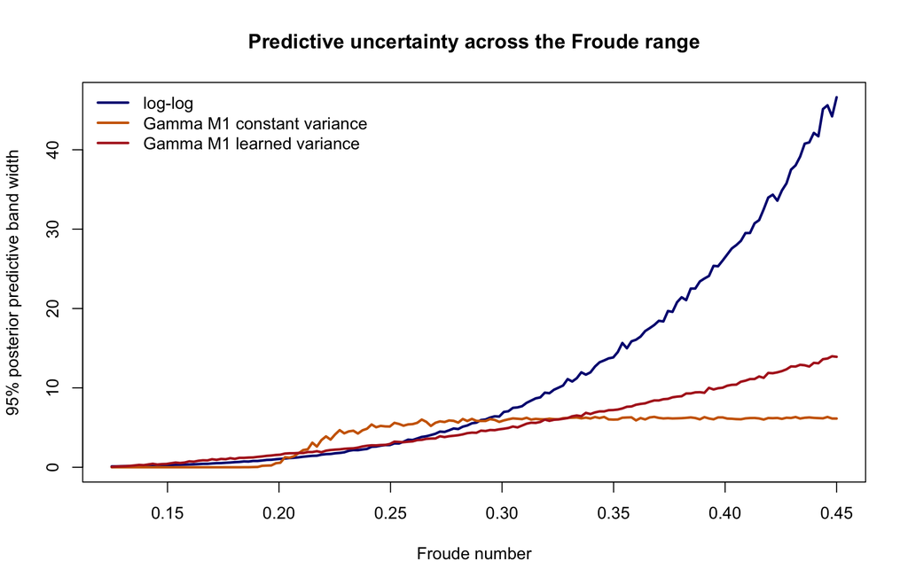

```r
pp_widths <- data.frame(
  Froude = fr_grid,
  loglog = pp_loglog$upper - pp_loglog$lower,
  gamma_constant = pp_M1_homo$upper - pp_M1_homo$lower,
  gamma_learned = pp_M1$upper - pp_M1$lower
)

plot_task4_widths <- function(file = NULL) {
  if (!is.null(file)) pdf(file, width = 8.5, height = 5.2)
  yr <- range(pp_widths[, -1], finite = TRUE)
  plot(pp_widths$Froude, pp_widths$loglog, type = "l", lwd = 2.4,
       col = "navy", ylim = yr, xlab = "Froude number",
       ylab = "95% posterior predictive band width",
       main = "Predictive uncertainty across the Froude range")
  lines(pp_widths$Froude, pp_widths$gamma_constant, lwd = 2.4,
        col = "darkorange3")
  lines(pp_widths$Froude, pp_widths$gamma_learned, lwd = 2.4,
        col = "firebrick")
  legend("topleft", bty = "n", lwd = 2.4,
         col = c("navy", "darkorange3", "firebrick"),
         legend = c("log-log", "Gamma M1 constant variance",
                    "Gamma M1 learned variance"))
  if (!is.null(file)) dev.off()
}

plot_task4_widths()
```